# DSCI 522 Forest Fire Analysis

Jim Pushor, Weifeng Guo  
November 24, 2018

# Report

## Introduction

The purpose of the project was to explore a data set featuring forest fires in a national park of Portugal. We decided on an inferential question: **Do fires that begin on weekends burn more area on average than fires that begin on weekdays?** This question was spun out of exploring the raw data set table (Table 1).

```r
library(knitr)
FFR_data <- read.csv("../data/FFRSample.csv")
FFC_data <- read.csv("../data/FFCSample.csv")
FFS_data <- read.csv("../data/Summarized_Data.csv")
```

*Table 1. Forest Fire Raw Dataset Sample*

| X | Y | month | day | FFMC | DMC | DC | ISI | temp | RH | wind | rain | area |
| --- | --- | --- | --- | --- | --- | --- | --- | --- | --- | --- | --- | --- |
| 6 | 5 | sep | sat | 92.5 | 121.1 | 674.4 | 8.6 | 25.1 | 27 | 4.0 | 0 | 1090.84 |
| 8 | 6 | aug | thu | 94.8 | 222.4 | 698.6 | 13.9 | 27.5 | 27 | 4.9 | 0 | 746.28 |
| 7 | 4 | jul | mon | 89.2 | 103.9 | 431.6 | 6.4 | 22.6 | 57 | 4.9 | 0 | 278.53 |
| 1 | 2 | sep | tue | 91.0 | 129.5 | 692.6 | 7.0 | 18.8 | 40 | 2.2 | 0 | 212.88 |
| 2 | 2 | sep | sat | 92.5 | 121.1 | 674.4 | 8.6 | 18.2 | 46 | 1.8 | 0 | 200.94 |
| 8 | 6 | aug | sun | 91.4 | 142.4 | 601.4 | 10.6 | 19.6 | 41 | 5.8 | 0 | 196.48 |

The raw data set included many features that are typical to forest fire analysis: wind speed, burn area, ambient temperature, dates, etc; however, considering question criteria outlined in *The Art of Data Science* By Roger Peng and Elizabeth Matsui, we chose a question that may not have been answered from this data.

Prior to doing further analysis, we needed to perform some data cleaning and wrangling. Using `Table 1` we removed any of the rows where the burnt area was zero. A zero value indicated an extremely small or neglibable burn area, which could skew our results. We wanted to focus on the the fire events that resulted in measurable burnt area.

In addition to removing zero valued rows for area burned. We classified the days of the week into two groups. One group, `Weekday` included all the weekdays and the other group, `Weekend` included all the weekend days.

*Table 2. Forest Fire Clean Dataset Sample*

| day | area |
| --- | --- |
| weekday | 0.36 |
| weekday | 0.43 |
| weekday | 0.47 |
| weekday | 0.55 |
| weekday | 0.61 |
| weekend | 0.71 |

## Visualization (EDA)

We explored our clean data by creating a distribution plot to compare the fire events on a weekend to a weekday. Our general observation was that they were similarly distributed relative to burnt area.

*Figure 1. Distribution Plot of Forest Fires Weekday vs. Weekend Days*

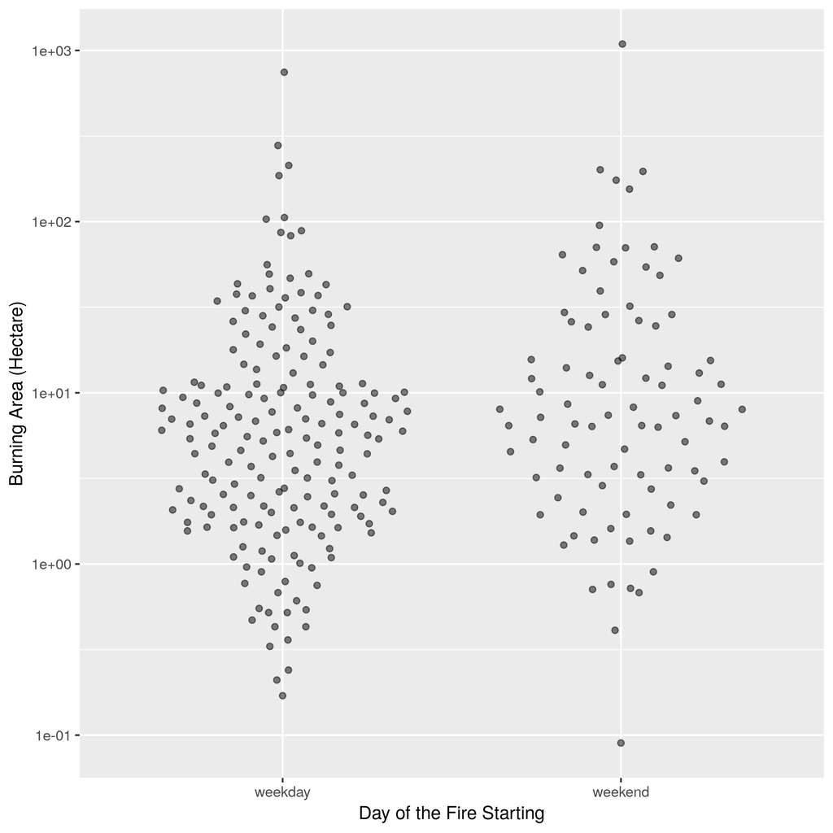

## Analysis

Through repeated simulations, we completed a difference in means null hypothesis test to determine if there was enough evidence to reject our null hypothesis: the difference in means is zero.

We produced a data summation table to communicate the critical values of our analysis between the two groups.

*Table 3. Data Summary Statistics*

| lower | upper | mean | day |
| --- | --- | --- | --- |
| 12.35087 | 30.51061 | 19.54287 | weekday |
| 17.50721 | 64.57353 | 34.88528 | weekend |

The following violin plot shows the distribution of the fires with the above confidence intervals and means noted for each group. The weekend group shows a larger range for the confidence intervals which suggests greater variation of values, as well as, effect of a relatively smaller data set.

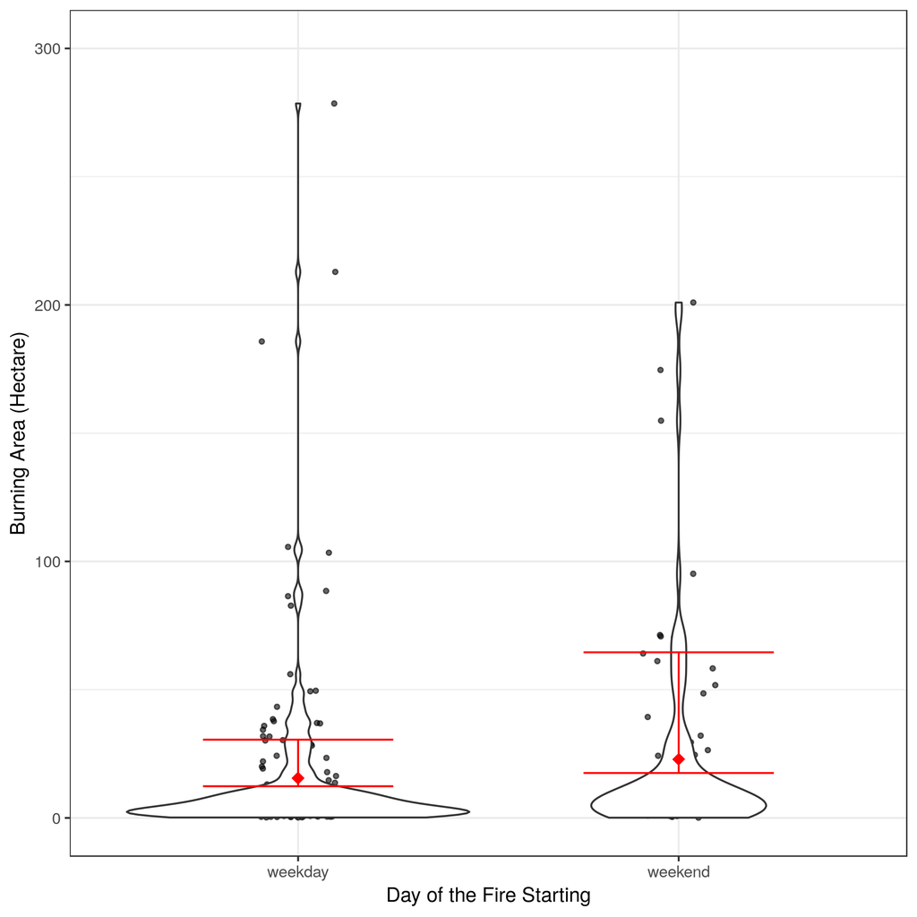

*Figure 3. Histogram of Null Hypothesis Distribution with Observed Diff of Means Value in Red* *95% Confidence Intervals in Blue*

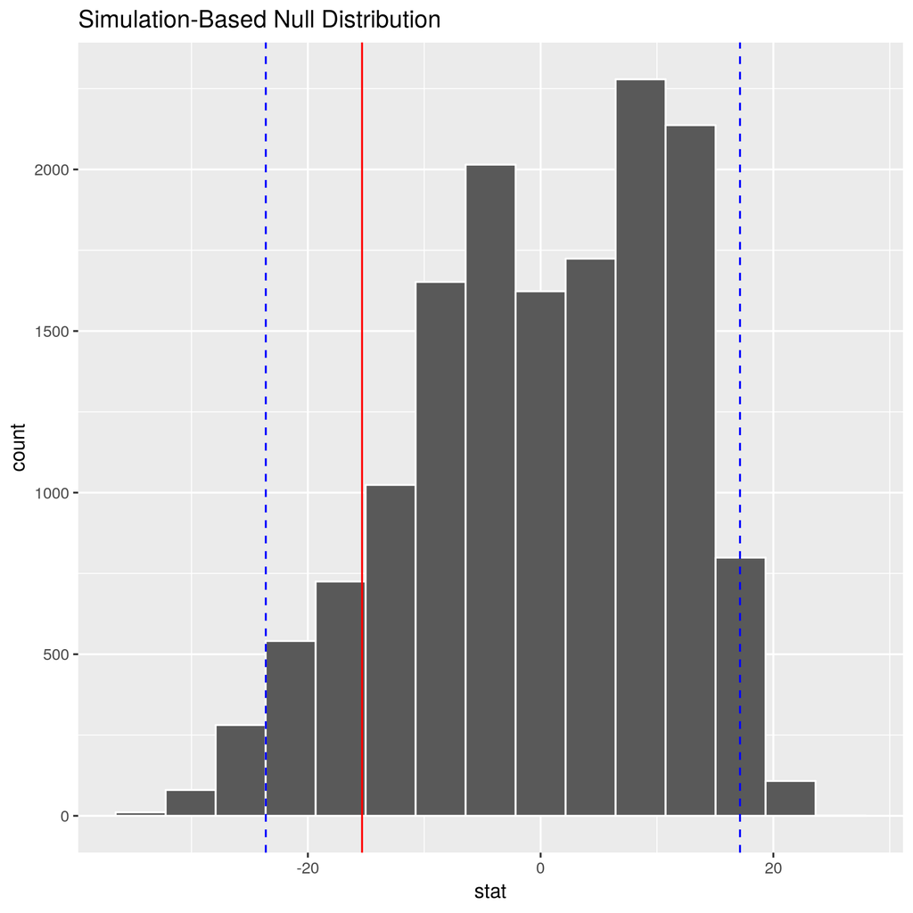

## Conclusion

The difference in means null hypothesis test produced not enough evidence to reject the null hypothesis. We can say that given the null hypothesis is true, the probability of us seeing a similar observation of at least or greater extreme is likely enough (~16%) for us to not dismiss the null hypothesis statement.

#### Critique and Future Steps

On reflection, there are a few things to consider:

- Though we are testing the difference of means of a subpopulation of a feature, it may be more appropriate to do muliple regression testing to understand how the different features impact the response variable: burnt area. Some features will be a stronger explanatory variable than others. It is difficult to conclude from our analysis that only the day of the week has an impact on the size of the fire, while isolating the other influentual factors like wind speed and temperature.
- We made an assumption that there may be a different response rate on weekends versus weekdays because of the availability of resources. This was not substantiated.
- We do not know the priority of fighting these fires in the park. It may be the case that the fire fighting is triaged based on risk to public safety, versus risk of area burned.

**References**

[UCI Machine Learning Data Sets](https://archive.ics.uci.edu/ml/datasets/Forest+Fires)  
Peng, Roger and Elizabeth Matsui. "The Art of Data Science: A Guide for Anyone Who Works with Data" Leanpub. 2018.